# Who survived the Titanic!

[figure not shown]

# Introduction

The sinking of the Titanic ship is one of the most infamous accidents in history. On April 15, 1912, Titanic sank after colliding with an iceberg resulting in the death of nearly 60% of the passengers. In this exercise, we will compare various machine learning models that could predict the survival rate using passenger data (like name, title, ticket number, gender, class, etc.)

# Objective

1. Model the survival rate of passengers in the Titanic dataset
2. End to end analysis
3. Compare various ML techniques

```r
setwd("C:/Users/khannva1/Documents/DS-Projects/Titanic")

# This function calculates the confusion matrix
cm <- function(model, data, target){
confusionMatrix(predict(model, newdata = data), target)
}
# Function to split the continous varibale into bins
custom_cut <- function(x, lower = 0, upper, by = 10,
                   sep = "-", above.char = "+") {

 labs <- c(paste(seq(lower, upper - by, by = by),
                 seq(lower + by - 1, upper - 1, by = by),
                 sep = sep),
           paste(upper, above.char, sep = ""))

 cut(floor(x), breaks = c(seq(lower, upper, by = by), Inf),
     right = FALSE, labels = labs)
}

'%ni%' <- Negate('%in%')
```

## Import the libraries and read data

I will import libraries such as *dplyr*, *tidyr*, *caret*, *gridExtra* and *purrr*.

```r
library("dplyr", quietly = T)
library("tidyr", quietly = T)
library("readr", quietly = T)
library("kableExtra", quietly = T)
library("caret", quietly = T)
library("stringr", quietly = T)
library("purrr", quietly = T)
library("gridExtra")
train <- suppressMessages(read_csv("C:\\Users\\khannva1\\Documents\\DS-Projects\\Titanic\\train.csv"))
test <- suppressMessages(read_csv("C:\\Users\\khannva1\\Documents\\DS-Projects\\Titanic\\test.csv"))
```

## Exploratory data analysis

Exploratory data analysis refers to exploring the data numerically and graphically.

```r
eda <- train
eda %>% head() %>%
  kable() %>% kable_styling(bootstrap_options = c("striped", "condensed", "responsive"), full_width = F, position = "center")
```

| PassengerId | Survived | Pclass | Name | Sex | Age | SibSp | Parch | Ticket | Fare | Cabin | Embarked |
| --- | --- | --- | --- | --- | --- | --- | --- | --- | --- | --- | --- |
| 1 | 0 | 3 | Braund, Mr. Owen Harris | male | 22 | 1 | 0 | A/5 21171 | 7.2500 | NA | S |
| 2 | 1 | 1 | Cumings, Mrs. John Bradley (Florence Briggs Thayer) | female | 38 | 1 | 0 | PC 17599 | 71.2833 | C85 | C |
| 3 | 1 | 3 | Heikkinen, Miss. Laina | female | 26 | 0 | 0 | STON/O2. 3101282 | 7.9250 | NA | S |
| 4 | 1 | 1 | Futrelle, Mrs. Jacques Heath (Lily May Peel) | female | 35 | 1 | 0 | 113803 | 53.1000 | C123 | S |
| 5 | 0 | 3 | Allen, Mr. William Henry | male | 35 | 0 | 0 | 373450 | 8.0500 | NA | S |
| 6 | 0 | 3 | Moran, Mr. James | male | NA | 0 | 0 | 330877 | 8.4583 | NA | Q |

```r
eda %>% group_by(Survived) %>%
  summarise(count = n(), percent = count/nrow(train)) %>%
  kable() %>% kable_styling(bootstrap_options = c("striped", "condensed", "responsive"), full_width = F, position = "center")
```

| Survived | count | percent |
| --- | --- | --- |
| 0 | 549 | 0.6161616 |
| 1 | 342 | 0.3838384 |

```r
col_type <- data.frame(Features = names(eda), Defination = c("Id", "Survival", "Ticket Class", "Name", "Sex", "Age", "Number of siblings/spouses", "Number of parents/childern", "Ticket number", "Passenger fare", "Cabin number","Boarding port"), Type = c("Numeric", "0 = No, 1 = Yes", "1 = 1st, 2 = 2nd, 3 = 3rd", "Character","Male, Female","Numeric","Numeric","Numeric","Character","Numeric","Character","C = Cherbourg, Q = Queenstown, S = Southampton"))

col_type %>%
  kable() %>% kable_styling(bootstrap_options = c("striped", "condensed", "responsive"), full_width = F, position = "center")
```

| Features | Defination | Type |
| --- | --- | --- |
| PassengerId | Id | Numeric |
| Survived | Survival | 0 = No, 1 = Yes |
| Pclass | Ticket Class | 1 = 1st, 2 = 2nd, 3 = 3rd |
| Name | Name | Character |
| Sex | Sex | Male, Female |
| Age | Age | Numeric |
| SibSp | Number of siblings/spouses | Numeric |
| Parch | Number of parents/childern | Numeric |
| Ticket | Ticket number | Character |
| Fare | Passenger fare | Numeric |
| Cabin | Cabin number | Character |
| Embarked | Boarding port | C = Cherbourg, Q = Queenstown, S = Southampton |

### Numeric variable

Age and Fare are numeric continuous variables and let us look at them based on the target variable.

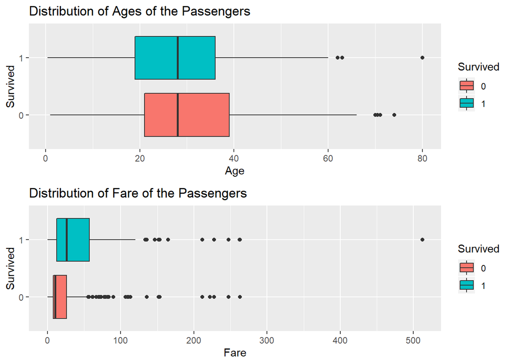

```r
eda$Survived <- as.factor(eda$Survived)

p1 <- eda %>% drop_na(Age) %>% ggplot(aes(y = Age, x= Survived, fill = Survived)) + geom_boxplot() +
    ggtitle(label = "Distribution of Ages of the Passengers") +
    ylab(label = "Age") + labs(fill = "Survived") + coord_flip()

p2 <- eda %>% drop_na(Fare) %>% ggplot(aes(y = Fare, x = Survived, fill = Survived)) + geom_boxplot() +
    ggtitle(label = "Distribution of Fare of the Passengers") +
    ylab(label = "Fare") + labs(fill = "Survived") + coord_flip()

grid.arrange(p1, p2, nrow=2)
```

**Age:** We note that most of the passengers were young from 20 to 40 years old in both the categories. The median age in the training dataset is 28 and the mean is 29.7 years.

**Fare:** Also, the fare shows that most of the passengers paid less than 100 Pounds per ticket. Further, it seems like there is a higher chance of survival if passengers have paid more.

### Categorical variables

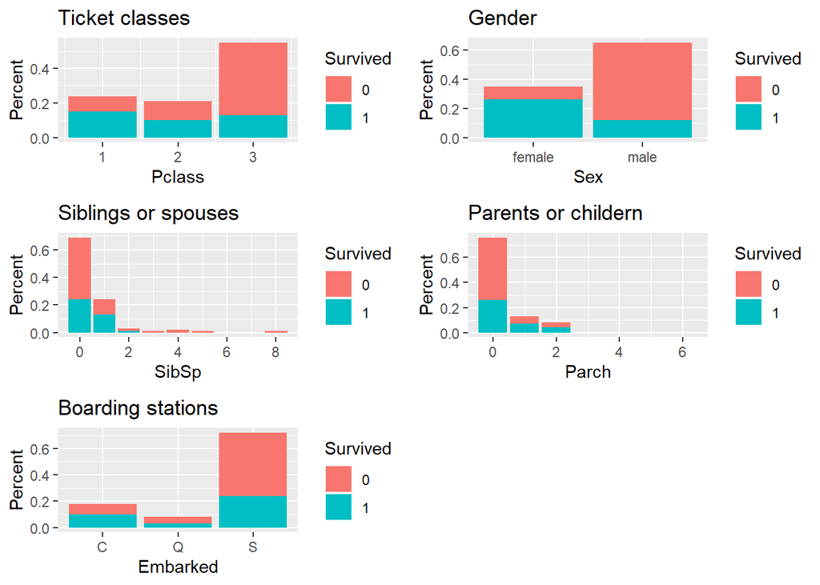

```r
p3 <- eda %>% drop_na(Pclass) %>% group_by(Pclass, Survived) %>%
  summarize(Percent = round(n()/nrow(.),2)) %>%
  ggplot(aes(x = Pclass, y = Percent, fill = Survived)) + geom_bar(stat = "identity") +
  ggtitle(label = "Ticket classes") +
  labs(fill = "Survived")

p4 <- eda %>% drop_na(Sex) %>% group_by(Sex, Survived) %>%
  summarize(Percent = round(n()/nrow(.),2)) %>%
  ggplot(aes(x = Sex, y = Percent, fill = Survived)) + geom_bar(stat = "identity") +
  ggtitle(label = "Gender") +
  labs(fill = "Survived")

p5 <- eda %>% drop_na(SibSp) %>% group_by(SibSp, Survived) %>%
    summarize(Percent = round(n()/nrow(.),2)) %>%
    ggplot(aes(x = SibSp, y = Percent, fill = Survived)) + geom_bar(stat = "identity") +
    ggtitle(label = "Siblings or spouses") +
    labs(fill = "Survived")

p6 <- eda %>% drop_na(Parch) %>% group_by(Parch, Survived) %>%
    summarize(Percent = round(n()/nrow(.),2)) %>%
    ggplot(aes(x = Parch, y = Percent, fill = Survived)) + geom_bar(stat = "identity") +
    ggtitle(label = "Parents or childern") +
    labs(fill = "Survived")

p7 <- eda %>% drop_na(Embarked) %>% group_by(Embarked, Survived) %>%
    summarize(Percent = round(n()/nrow(.),2)) %>%
    ggplot(aes(x = Embarked, y = Percent, fill = Survived)) + geom_bar(stat = "identity") +
    ggtitle(label = "Boarding stations") +
    labs(fill = "Survived")

grid.arrange(p3, p4, p5, p6, p7, nrow=3)
```

1. **Pclass:** It looks like first-class passengers had a higher rate of survival. It is not an unexpected finding as people with first-class tickets would have been given preference over people with lower-class tickets.
2. **Gender:** High survival chance if the passenger was female. It makes sense because females and children would have been given preference during evacuation.
3. **Number of Siblings or Spouse:** Survival rate is high for passengers with Siblings or Spouses. It may be due to the fact that more trusted people you have onboard more the chance of getting reliable information. Reliable information is critical for survival.
4. **Number of Parents or children:** Similarly, the survival rate is higher for passengers with Parents or children. I think the same logic applies as above.
5. **Boarding station:** It turns out that people who board form Cherbourg and Queenstown station have a higher rate of survival. It will be interesting to dig deeper and see if the majority of the people who board from these two stations have first- or second-class tickets. In case that is true, it will help explain the observation.

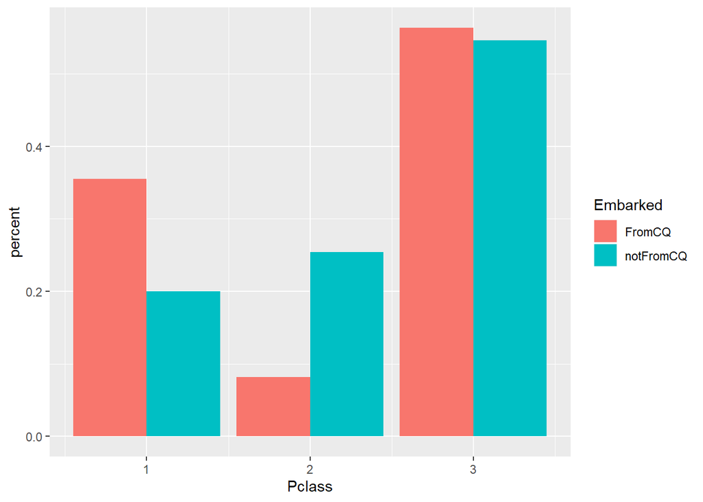

```r
not_cq <- eda %>% filter(Embarked %ni% c('C','Q')) %>%
  group_by(Pclass)%>% summarise(n = n()) %>%
  mutate(percent = n/sum(n))

cq <- eda %>% filter(Embarked %in% c('C','Q')) %>%
  group_by(Pclass)%>% summarise(n = n()) %>%
  mutate(percent = n/sum(n))

not_cq$Embarked <- 'notFromCQ'
cq$Embarked <- 'FromCQ'

rbind(not_cq,cq) %>% ggplot(aes(x = Pclass, y = percent, fill = Embarked)) +
  geom_bar(stat = "identity", position = "dodge")
```

Indeed we find that there are more first-class passengers from Cherbourg and Queenstown stations.

### Multivariate analysis

1. Passenger survival by Pclass and Age and Pclass and Fare

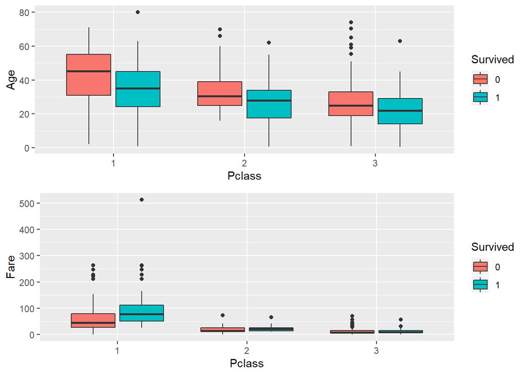

```r
eda$Pclass <- as.factor(eda$Pclass)

p8 <- eda %>% drop_na(Age) %>% ggplot(aes(x = Pclass, y = Age)) + geom_boxplot(aes(fill = Survived))

p9 <- eda %>% drop_na(Fare) %>% ggplot(aes(x = Pclass, y = Fare)) + geom_boxplot(aes(fill = Survived))

grid.arrange(p8, p9, nrow = 2)
```

## Data wrangling

Combine the train and test dataset into one dataset for easier imputation of missing values. Create an *isTrain* binary logical variable to distinguish between train and test set for later use.

```r
train <- train %>% mutate(isTrain = TRUE)
survived  <- train %>% pull(Survived)
train <- train %>% select(-c(Survived))

test <- test %>% mutate(isTrain = FALSE)

df <- bind_rows(train, test)
```

### Missing values

A quick investigation of the combined dataset shows that there are missing values in *Age*, *Cabin*, *Embarked*, *Fare*. *Cabin* has a large number of missing values (~77%) followed by *Age* (~20%), 2 values in *Embarked* and 1 in *Fare*.

```r
missing.values <- df %>% gather(key = "key", value = "val") %>% mutate(is.missing = is.na(val)) %>%
  # Calculate missing in each category
  group_by(key) %>% mutate(total = n()) %>%
  group_by(key,total,is.missing) %>%
  summarise(num.missing = n()) %>%
  # claculate percentage
  mutate(pct = num.missing/total * 100)

  names <- (missing.values %>% filter(is.missing == TRUE) %>%
    arrange(desc(pct)))$key

# Change the column names for better readability
ungroup(missing.values) %>% filter(is.missing == TRUE) %>% select(-c('pct','total', 'is.missing')) %>% rename("Column" = "key", "Missing" = "num.missing") %>% kable() %>% kable_styling(bootstrap_options = c("striped", "condensed", "responsive"), full_width = F, position = "center")
```

| Column | Missing |
| --- | --- |
| Age | 263 |
| Cabin | 1014 |
| Embarked | 2 |
| Fare | 1 |

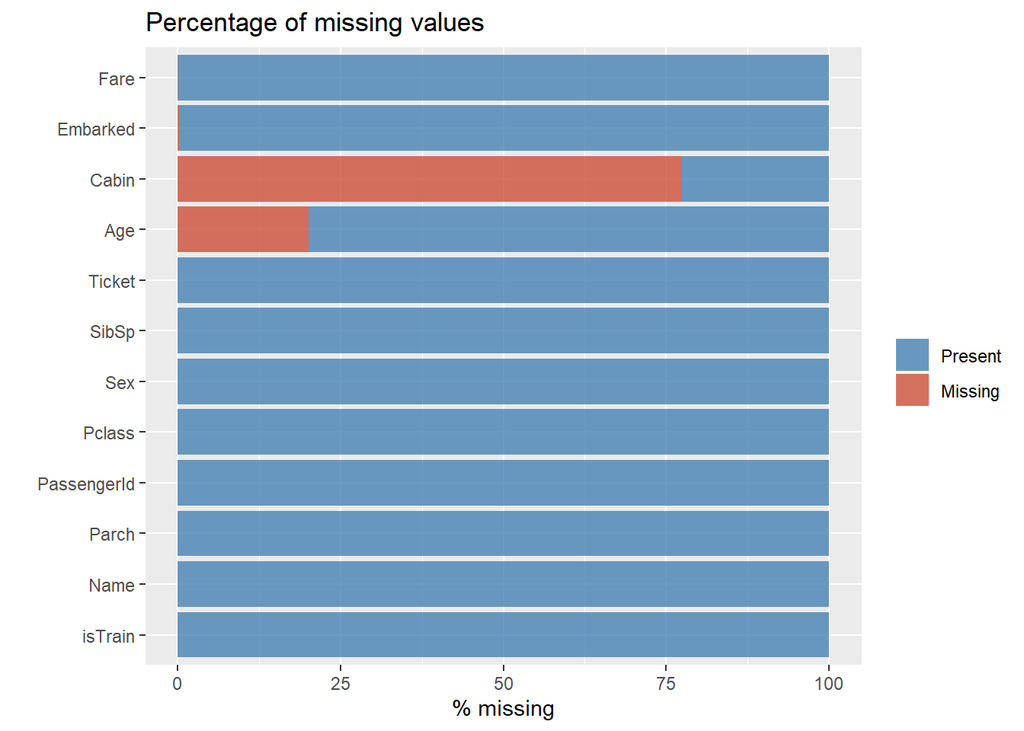

```r
# Plot missing values
p10 <- ggplot(missing.values) + geom_bar(aes( x= reorder(key, desc(pct)), y = pct, fill = is.missing), stat = 'identity', alpha = 0.8) + scale_fill_manual(name = "", values = c('steelblue','tomato3'), label = c("Present", "Missing")) + coord_flip() + labs(title = "Percentage of missing values",x = '',y = '% missing')

p10
```

### Impute missing values

Let us impute the missing values.

1. For *Cabin* I will extract and store the first letter of the Cabin column and I will replace all the missing values with the letter ‘U’ referring to ‘Unknown’.
2. For *Embarked* I will replace the missing value with ‘S’ as it the most common station to embark.
3. For *Fare* and *Age* I will build a linear and decision tree model to predict the missing values.

#### Cabin

Let us extract first letter from the Cabin and replace missing values with the *U*. Also, I will create a new binary variable called *CabinMissing* to encode values which are missing or present in Cabin column.

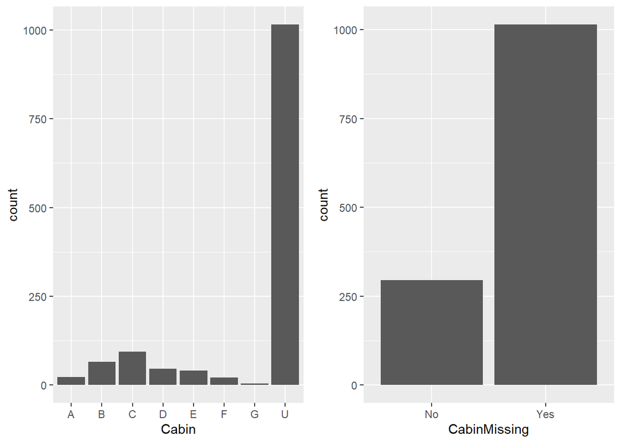

```r
# Replace Cabin with missing or not missing
df <- df %>% mutate(CabinMissing = ifelse(is.na(Cabin), "Yes","No"))
df$Cabin <- str_extract(df$Cabin, "\\w") %>% ifelse(is.na(.), "U",.)
df$Cabin <- ifelse(df$Cabin == 'T', "U", df$Cabin)
p11 <- df %>% ggplot(aes(x = Cabin)) + geom_bar()
p12 <- df %>% ggplot(aes(x = CabinMissing)) + geom_bar()

grid.arrange(p11, p12, ncol = 2)
```

#### Embarked

Since *S* is the most common boarding station so will fill the two missing values in the Embarked column by *S*.

```r
# Fill in the missing values in Embarked column.
df$Embarked <- ifelse(is.na(df$Embarked), "S", df$Embarked)
```

#### Fare

To fill in the one missing value we will create a *cubist* model to predict Fare. The built model has good R-squared value.

```r
# By building the model
fare_lt_65 <- df %>% filter(Fare <= 65) %>% select(Pclass, Sex, Age, Parch, SibSp, Embarked, Fare)
fare.formula <- as.formula(Fare ~ Pclass + Sex + Parch + Embarked + SibSp)
ctrl <- trainControl(method = "repeatedcv",
                     repeats = 5)

model.fare <- train(fare.formula, data = fare_lt_65, method = "cubist", trControl = ctrl, tuneLength = 5)
# Look at the model
model.fare
```

```
## Cubist
##
## 1137 samples
##    5 predictor
##
## No pre-processing
## Resampling: Cross-Validated (10 fold, repeated 5 times)
## Summary of sample sizes: 1024, 1022, 1024, 1022, 1022, 1024, ...
## Resampling results across tuning parameters:
##
##   committees  neighbors  RMSE      Rsquared   MAE
##    1          0          7.573140  0.7021458  3.640312
##    1          5          7.643969  0.6983493  4.027369
##    1          9          7.616408  0.7008678  3.990902
##   10          0          7.511976  0.7074433  3.681837
##   10          5          7.618120  0.6999233  4.007815
##   10          9          7.593728  0.7015785  3.995340
##   20          0          7.501900  0.7081516  3.684367
##   20          5          7.619760  0.6998380  4.008738
##   20          9          7.594458  0.7015081  3.997459
##
## RMSE was used to select the optimal model using the smallest value.
## The final values used for the model were committees = 20 and neighbors = 0.
```

```r
to_predict <- df %>% filter(is.na(Fare))%>%select(Pclass, Sex, Age, Parch, Embarked, SibSp)

fare.predictions <- predict(model.fare, newdata = to_predict)

df$Fare <- ifelse(is.na(df$Fare), fare.predictions, df$Fare)
```

#### Ages

```r
# Fill in the missing values in age column
df <- df %>% mutate(AgeMissing = ifelse(is.na(Age), "Yes","No"))

df$Title <- str_extract(df$Name, ",\\s*\\w+") %>% str_remove(., pattern = ", ")

df$Title[df$Title %in% c('Capt', 'Col', 'Major', 'the')] <- 'Officer'
df$Title[df$Title %in% c('Don','Dr','Rev','Sir','Jonkheer','Countess','Lady','Dona')] <- 'Royalty'
df$Title[df$Title %in% c('Mrs','Mme')] <- 'Mrs'
df$Title[df$Title %in% c('Ms','Mlle')] <- 'Miss'

age_lt_66 <- df %>% filter(Age <= 66) %>% select(Pclass, Parch, SibSp, Embarked, Title, Age)

ctrl <- trainControl(method = "repeatedcv",
                     repeats = 5)

age.formula <- as.formula(Age ~ Pclass + SibSp + Parch + Embarked + Title)
# Look at the model
model.age <- train(age.formula, data = age_lt_66, method = "cubist", trControl = ctrl, tuneLength = 5)

model.age
```

```
## Cubist
##
## 1037 samples
##    5 predictor
##
## No pre-processing
## Resampling: Cross-Validated (10 fold, repeated 5 times)
## Summary of sample sizes: 934, 935, 933, 934, 933, 932, ...
## Resampling results across tuning parameters:
##
##   committees  neighbors  RMSE      Rsquared   MAE
##    1          0          10.60032  0.4295164  8.175854
##    1          5          10.43585  0.4492280  8.102004
##    1          9          10.40984  0.4494488  8.104011
##   10          0          10.62397  0.4279340  8.283237
##   10          5          10.37905  0.4539331  8.082850
##   10          9          10.33975  0.4554834  8.081092
##   20          0          10.64049  0.4256067  8.286202
##   20          5          10.38884  0.4530973  8.084775
##   20          9          10.35379  0.4541195  8.086461
##
## RMSE was used to select the optimal model using the smallest value.
## The final values used for the model were committees = 10 and neighbors = 9.
```

```r
to_predict <- df %>% filter(is.na(Age))%>%select(Pclass, Sex, Fare, Parch, Embarked, SibSp, Title)
age.predictions <- predict(model.age, newdata = to_predict)

df$Age <- ifelse(is.na(df$Age), age.predictions, df$Age)
```

Like Cabin we will create a new variable called *AgeMissing* to encode if the Age information was missing in the original dataset.

## Feature engineering

Let us create new variables and remove the id variables.

1. Convert *Pclass* into factor variable.
2. Make a new variable called *Ticket_len* by calculating the length of the ticket characters.
3. Make a new variable called *Ticket_parts* by calculating the parts in the tickets.
4. Make a new variable called *Family* by adding Parch, SibSp and 1.
5. A binary variable called *Large Family* if the family has more than 4 members.
6. A binary variable called *fare_gt_50* where fare >= 50.
7. Remove Name, PassengerId and Ticket variables.
8. Convert all character variables to factor variables.
9. Convert factor variables to one-hot encoded variables.
10. Convert age and fare variables into categorical variable by binning.
11. Create a new variable called *family_size* to categorize the size of the family.

```r
# Convert Pclass into factor variable
df <- df %>% mutate(Pclass = ifelse(Pclass == 1, "One", ifelse(Pclass == 2, "Two", "Three")))
df$Pclass <- as.factor(df$Pclass)

# make bins of age and fare
df$agebins <- custom_cut(df$Age, upper = 70, by = 9)
df$farebins <- custom_cut(df$Fare, upper = 60, by = 10)

df <- df %>% mutate(Ticket_len = map_dbl(Ticket, nchar))
df <- df %>% mutate(Ticket_parts = str_split(Ticket, pattern = " ") %>% map_dbl(., length))

df <- df %>% mutate(family = (Parch + SibSp + 1))

df <- df %>% mutate(family_size = case_when(family == 1 ~ "Alone",
                                                 family %in% c(2,3,4) ~ "Small",
                                                 family %in% c(5,6) ~ "Medium",
                                                 family %in% c(7,8,11) ~ "Large"))


df$LargeFamily <- ifelse(df$family > 4, "Yes", "No")

df <- df %>% mutate(fare_gt_50 = ifelse(Fare >= 50, "Yes", "No"))

df <- df %>% mutate(PclassThree_female = ifelse(Pclass == "Three" & Sex == "female", "Yes","No"))
# Remove columns not required
df <- df %>% select(-c(PassengerId, Name, Ticket))
df <- df %>% mutate_if(is.character, as.factor)
df_copy <- df # Make a copy

# One hot encode the categorical variables
dmy <- dummyVars("~Pclass + Sex + Embarked + Title + fare_gt_50 + AgeMissing + LargeFamily + agebins + farebins + family_size + CabinMissing + Cabin + PclassThree_female" , data = df)
ohe_df <- predict(dmy, newdata = df) %>% as.data.frame()

num_df <- df %>% select_if(funs(is.numeric(.)| is.logical(.))) %>% as.data.frame()
df <- cbind(ohe_df,num_df)


# # Preprocess
pre_process <- df %>%  preProcess(., method = c("center","scale"))
df <- predict(pre_process, newdata = df)
```

## Train Test split

Split the dataset into train, test and validation set. Validation set will be used to get the model performance however should not be used as sole cretirea for model selection. It should be used along with cross-validation performance.

```r
train <- df %>% filter(isTrain == TRUE) %>% select(-c(isTrain))
test_x <- df %>% filter(isTrain == FALSE) %>% select(-c(isTrain))

train_x_full <- train
train_y_full <- as.factor(make.names(survived))


metric <- "logLoss"

ctrl <- trainControl(
  method = "cv",
  number = 5,
  savePredictions = "all",
  classProbs = TRUE,
  summaryFunction = multiClassSummary,
  verboseIter = FALSE)

# split the data
set.seed(3000)
inTrain <- createDataPartition(survived, p = 0.10, list = FALSE)

train_x <- train[-inTrain,]
val_x <- train[inTrain,]

train_y <- as.factor(make.names(survived))[-inTrain]
val_y <- as.factor(make.names(survived))[inTrain]
```

## Logistic Regression

Train the model with all the features.

```r
set.seed(3000)

weights <- c(0.623,1.000)

model_weights <- ifelse(train_y == "0", weights[1], weights[2])

model_glm <- train(x = train_x, y = train_y, method = "glm", trControl = ctrl, metric = metric, weights = model_weights)

# Evaluate the model on the test data
cm_glm <- cm(model = model_glm, data = val_x, target = val_y)

print(cm_glm)
```

```
## Confusion Matrix and Statistics
##
##           Reference
## Prediction X0 X1
##         X0 49 13
##         X1  4 24
##
##                Accuracy : 0.8111
##                  95% CI : (0.7149, 0.8859)
##     No Information Rate : 0.5889
##     P-Value [Acc > NIR] : 6.123e-06
##
##                   Kappa : 0.595
##
##  Mcnemar's Test P-Value : 0.05235
##
##             Sensitivity : 0.9245
##             Specificity : 0.6486
##          Pos Pred Value : 0.7903
##          Neg Pred Value : 0.8571
##              Prevalence : 0.5889
##          Detection Rate : 0.5444
##    Detection Prevalence : 0.6889
##       Balanced Accuracy : 0.7866
##
##        'Positive' Class : X0
##
```

### Importance of variables

```r
summary(model_glm)
```

```
##
## Call:
## NULL
##
## Deviance Residuals:
##     Min       1Q   Median       3Q      Max
## -2.9249  -0.5224  -0.3652   0.3096   2.4628
##
## Coefficients: (16 not defined because of singularities)
##                         Estimate Std. Error z value Pr(>|z|)
## (Intercept)             -0.45390    2.73767  -0.166  0.86832
## Pclass.One               0.32078    0.27729   1.157  0.24733
## Pclass.Three             0.00771    0.23687   0.033  0.97403
## Pclass.Two                    NA         NA      NA       NA
## Sex.female               7.62913  391.69821   0.019  0.98446
## Sex.male                      NA         NA      NA       NA
## Embarked.C               0.23017    0.12390   1.858  0.06321 .
## Embarked.Q               0.19259    0.11736   1.641  0.10079
## Embarked.S                    NA         NA      NA       NA
## Title.Master             0.67411    0.22338   3.018  0.00255 **
## Title.Miss              -4.44986  328.25015  -0.014  0.98918
## Title.Mr                -0.09633    0.40214  -0.240  0.81069
## Title.Mrs               -3.85917  293.11257  -0.013  0.98950
## Title.Officer            0.12614    0.10881   1.159  0.24634
## Title.Royalty                 NA         NA      NA       NA
## fare_gt_50.No           -0.51663    0.48086  -1.074  0.28265
## fare_gt_50.Yes                NA         NA      NA       NA
## AgeMissing.No            0.04019    0.11800   0.341  0.73338
## AgeMissing.Yes                NA         NA      NA       NA
## LargeFamily.No           0.61357    0.25898   2.369  0.01783 *
## LargeFamily.Yes               NA         NA      NA       NA
## `agebins.0-8`            0.96710    0.73220   1.321  0.18657
## `agebins.9-17`           0.74547    0.65766   1.134  0.25699
## `agebins.18-26`          1.07104    1.02604   1.044  0.29655
## `agebins.27-35`          1.26908    0.89477   1.418  0.15610
## `agebins.36-44`          0.64850    0.57037   1.137  0.25554
## `agebins.45-53`          0.47543    0.36861   1.290  0.19712
## `agebins.54-62`          0.15726    0.25487   0.617  0.53722
## `agebins.70+`                 NA         NA      NA       NA
## `farebins.0-9`           0.93771    0.61531   1.524  0.12752
```

[output cut: 24 more lines]

```
## Parch                   -0.04963    0.25644  -0.194  0.84654
## Fare                     0.28155    0.20937   1.345  0.17871
## Ticket_len              -0.20096    0.20661  -0.973  0.33072
## Ticket_parts             0.35034    0.21312   1.644  0.10020
## family                        NA         NA      NA       NA
## ---
## Signif. codes:  0 '***' 0.001 '**' 0.01 '*' 0.05 '.' 0.1 ' ' 1
##
## (Dispersion parameter for binomial family taken to be 1)
##
##     Null deviance: 1064.44  on 800  degrees of freedom
## Residual deviance:  584.12  on 758  degrees of freedom
## AIC: 670.12
##
## Number of Fisher Scoring iterations: 14
```

```r
# Let us select few variables
df_copy_selected <- df_copy %>% select(c(Pclass,Embarked,Title,LargeFamily,Age,Cabin,farebins,family,AgeMissing,Sex,isTrain))
#df_copy_selected <- df_copy %>% select(c(Pclass,Embarked,Title,LargeFamily,Age,farebins,PclassThree_female,isTrain))

train <- df_copy_selected %>% filter(isTrain == TRUE) %>% select(-c(isTrain)) %>% as.data.frame()
test_x <- df_copy_selected %>% filter(isTrain == FALSE) %>% select(-c(isTrain)) %>% as.data.frame()

train_x_full <- train
train_y_full <- as.factor(make.names(survived))

# split the data
set.seed(3000)
inTrain <- createDataPartition(survived, p = 0.10, list = FALSE)

train_x <- train[-inTrain,]
val_x <- train[inTrain,]

train_y <- as.factor(make.names(survived))[-inTrain]
val_y <- as.factor(make.names(survived))[inTrain]

set.seed(3000)

weights <- c(0.623,1.000)

model_weights <- ifelse(train_y == "0", weights[1], weights[2])

model_glm_selected <- train(x = train_x, y = train_y, method = "glm", trControl = ctrl, metric = metric, weights = model_weights, preProcess = c("center", "scale"))

# Evaluate the model on the test data
cm_glm_selected <- cm(model = model_glm_selected, data = val_x, target = val_y)

print(cm_glm_selected)
```

```
## Confusion Matrix and Statistics
##
##           Reference
## Prediction X0 X1
##         X0 49  6
##         X1  4 31
##
##                Accuracy : 0.8889
##                  95% CI : (0.8051, 0.9454)
##     No Information Rate : 0.5889
##     P-Value [Acc > NIR] : 3.821e-10
##
##                   Kappa : 0.7686
##
##  Mcnemar's Test P-Value : 0.7518
##
##             Sensitivity : 0.9245
##             Specificity : 0.8378
##          Pos Pred Value : 0.8909
##          Neg Pred Value : 0.8857
##              Prevalence : 0.5889
##          Detection Rate : 0.5444
##    Detection Prevalence : 0.6111
##       Balanced Accuracy : 0.8812
##
##        'Positive' Class : X0
##
```

```r
# Let us build the model with the whole training set
model_weights <- ifelse(train_y_full == "0", weights[1], weights[2])

model_glm_full <- train(x = train_x_full, y = train_y_full, method = "glm", trControl = ctrl, metric = metric, weights = model_weights, preProcess = c("center", "scale"))
```

## Random forest

Let us use the same variables to build the random forest model. RF can take care of outliers so no need for pre-processing of the data.

```r
set.seed(3000)

weights <- c(0.623,1.000)

model_weights <- ifelse(train_y == "0", weights[1], weights[2])

model_rf <- train(x = train_x, y = train_y, method = "rf", trControl = ctrl, metric = metric, weights = model_weights, tuneLength = 8)

# Evaluate the model on the validation data
cm_rf<- cm(model = model_rf, data = val_x, target = val_y)

print(cm_rf)
```

```
## Confusion Matrix and Statistics
##
##           Reference
## Prediction X0 X1
##         X0 51 14
##         X1  2 23
##
##                Accuracy : 0.8222
##                  95% CI : (0.7274, 0.8948)
##     No Information Rate : 0.5889
##     P-Value [Acc > NIR] : 1.951e-06
##
##                   Kappa : 0.6139
##
##  Mcnemar's Test P-Value : 0.00596
##
##             Sensitivity : 0.9623
##             Specificity : 0.6216
##          Pos Pred Value : 0.7846
##          Neg Pred Value : 0.9200
##              Prevalence : 0.5889
##          Detection Rate : 0.5667
##    Detection Prevalence : 0.7222
##       Balanced Accuracy : 0.7919
##
##        'Positive' Class : X0
##
```

```r
# Let us build the model with the full training data
model_weights <- ifelse(train_y_full == "0", weights[1], weights[2])

model_rf_full <- train(x = train_x_full, y = train_y_full, method = "rf", trControl = ctrl, metric = metric, weights = model_weights, tuneLength = 8)
```

## GLM Boost

Let us try GLM Boost model.

```r
set.seed(3000)

weights <- c(0.623,1.000)

model_weights <- ifelse(train_y == "0", weights[1], weights[2])

model_glmboost<- train(x = train_x, y = train_y, method = "glmboost", trControl = ctrl, metric = metric, weights = model_weights, tuneLength = 10, preProcess = c("center","scale"))

# Evaluate the model on the test data
cm_glmboost <- cm(model = model_glmboost, data = val_x, target = val_y)

print(cm_glmboost)
```

```
## Confusion Matrix and Statistics
##
##           Reference
## Prediction X0 X1
##         X0 49  8
##         X1  4 29
##
##                Accuracy : 0.8667
##                  95% CI : (0.7787, 0.9292)
##     No Information Rate : 0.5889
##     P-Value [Acc > NIR] : 9.36e-09
##
##                   Kappa : 0.7201
##
##  Mcnemar's Test P-Value : 0.3865
##
##             Sensitivity : 0.9245
##             Specificity : 0.7838
##          Pos Pred Value : 0.8596
##          Neg Pred Value : 0.8788
##              Prevalence : 0.5889
##          Detection Rate : 0.5444
##    Detection Prevalence : 0.6333
##       Balanced Accuracy : 0.8542
##
##        'Positive' Class : X0
##
```

```r
model_weights <- ifelse(train_y_full == "0", weights[1], weights[2])

model_glmboost_full <- train(x = train_x_full, y = train_y_full, method = "glmboost", trControl = ctrl, metric = metric, tuneLength = 10, weights = model_weights, preProcess = c("center","scale"))
```

# Submit to Kaggle

Generate the prediction file to submit the predictions to Kaggle.

```r
  # Predict the model on the test data
  pred <- predict(model_glm_full, test_x) %>% str_remove(., pattern = "X") %>% as.integer()
  sample_submission <- read.csv("gender_submission.csv", header = TRUE, stringsAsFactors = F)
  sample_submission$Survived <- pred
  write.csv(sample_submission, file = "glm_submission.csv",quote = FALSE, row.names = FALSE)
```

I got the score of 79.4% in Kaggle which is not bad however, it is way below the test score I got in the GLM model (~88%) which suggest that my model has overfit the training data.